# Exploratory_analysis

Jazmin MM ft datatrail

2024-07-31

**“Correlation does not imply causation”**

## Getting data

We will use a dataset from <Kaggle.com> that contains 120 years of Olympics history on athletes and results. If you don’t have an account on Kaggle, create one and go to the link https://www.kaggle.com/heesoo37/120-years-of-olympic-history-athletes-and-results and under “Data Sources” download the athlete_events.csv to your computer.

```r
library(readr)

atlt_events <- read.csv("C:\\Users\\Jazmin\\Documents\\Rp\\athlete_events.csv\\athlete_events.csv")
```

## Using the skimr package to have a summary of the data

```r
library(skimr)
skim(atlt_events)
```

Data summary

| Name | atlt_events |
| --- | --- |
| Number of rows | 271116 |
| Number of columns | 15 |
| _______________________ |  |
| Column type frequency: |  |
| character | 10 |
| numeric | 5 |
| ________________________ |  |
| Group variables | None |

**Variable type: character**

| skim_variable | n_missing | complete_rate | min | max | empty | n_unique | whitespace |
| --- | --- | --- | --- | --- | --- | --- | --- |
| Name | 0 | 1.00 | 2 | 108 | 0 | 134732 | 0 |
| Sex | 0 | 1.00 | 1 | 1 | 0 | 2 | 0 |
| Team | 0 | 1.00 | 2 | 47 | 0 | 1184 | 0 |
| NOC | 0 | 1.00 | 3 | 3 | 0 | 230 | 0 |
| Games | 0 | 1.00 | 11 | 11 | 0 | 51 | 0 |
| Season | 0 | 1.00 | 6 | 6 | 0 | 2 | 0 |
| City | 0 | 1.00 | 4 | 22 | 0 | 42 | 0 |
| Sport | 0 | 1.00 | 4 | 25 | 0 | 66 | 0 |
| Event | 0 | 1.00 | 15 | 85 | 0 | 765 | 0 |
| Medal | 231333 | 0.15 | 4 | 6 | 0 | 3 | 0 |

**Variable type: numeric**

| skim_variable | n_missing | complete_rate | mean | sd | p0 | p25 | p50 | p75 | p100 | hist |
| --- | --- | --- | --- | --- | --- | --- | --- | --- | --- | --- |
| ID | 0 | 1.00 | 68248.95 | 39022.29 | 1 | 34643 | 68205 | 102097.2 | 135571 | ▇▇▇▇▇ |
| Age | 9474 | 0.97 | 25.56 | 6.39 | 10 | 21 | 24 | 28.0 | 97 | ▇▃▁▁▁ |
| Height | 60171 | 0.78 | 175.34 | 10.52 | 127 | 168 | 175 | 183.0 | 226 | ▁▂▇▂▁ |
| Weight | 62875 | 0.77 | 70.70 | 14.35 | 25 | 60 | 70 | 79.0 | 214 | ▃▇▁▁▁ |
| Year | 0 | 1.00 | 1978.38 | 29.88 | 1896 | 1960 | 1988 | 2002.0 | 2016 | ▁▂▃▆▇ |

## There are some missing values in the data

Second, we can see that there are some outliers in some of the numerical variables. For example, look at the summary of the variable *Age*

```r
subset(atlt_events, atlt_events$Age == 97)
```

```
##            ID                   Name Sex Age Height Weight          Team NOC
## 257055 128719 John Quincy Adams Ward   M  97     NA     NA United States USA
##              Games Year Season      City            Sport
## 257055 1928 Summer 1928 Summer Amsterdam Art Competitions
##                                              Event Medal
## 257055 Art Competitions Mixed Sculpturing, Statues  <NA>
```

## There is an outlier in the Age variable

You can see that the age of most individuals in the sample are between 18-35.

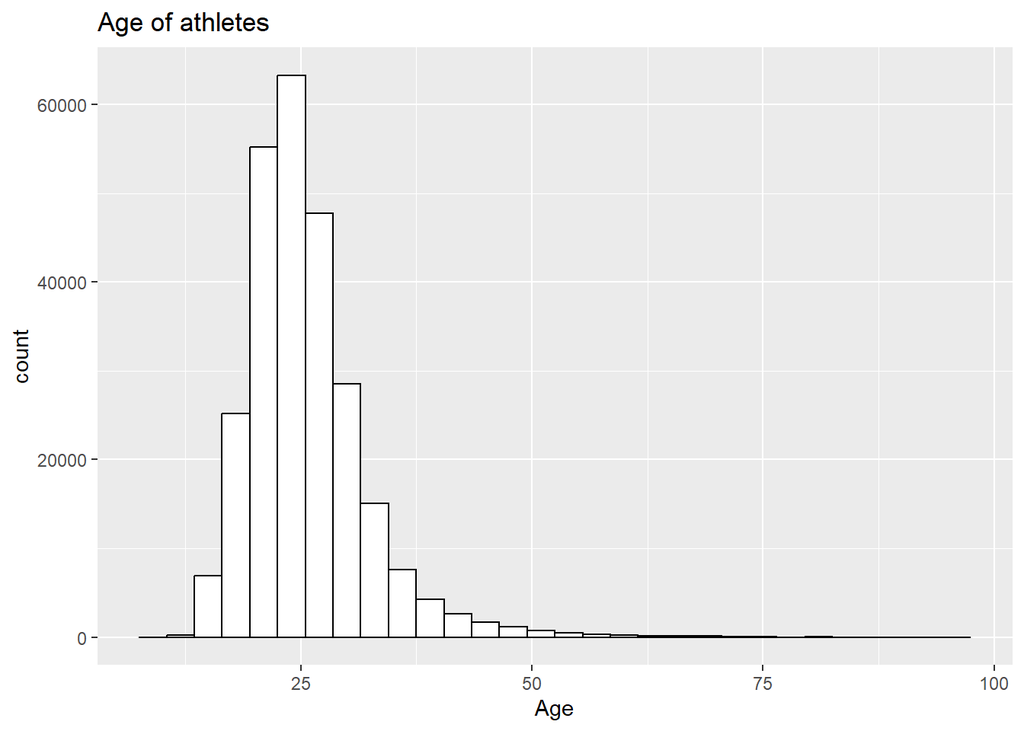

```r
library(ggplot2)
ggplot(atlt_events, aes(x = Age)) +
  geom_histogram(color = "black", fill = "white")+
  labs( title = "Age of athletes")
```

## Histogram of the variable Age

Now, rather than just summarizing the data points within a single variable, we can look at how two or more variables might be related to each other. For instance, we like to know if there is an association between age of athletes and their gender. One of the ways to do this is to look at a boxplot of age grouped by gender, i.e., the distribution of age separated for male and female athletes. Boxplot shows the distribution of the variable age for the gender groups. You can see that the average age is slightly higher for men than for women.

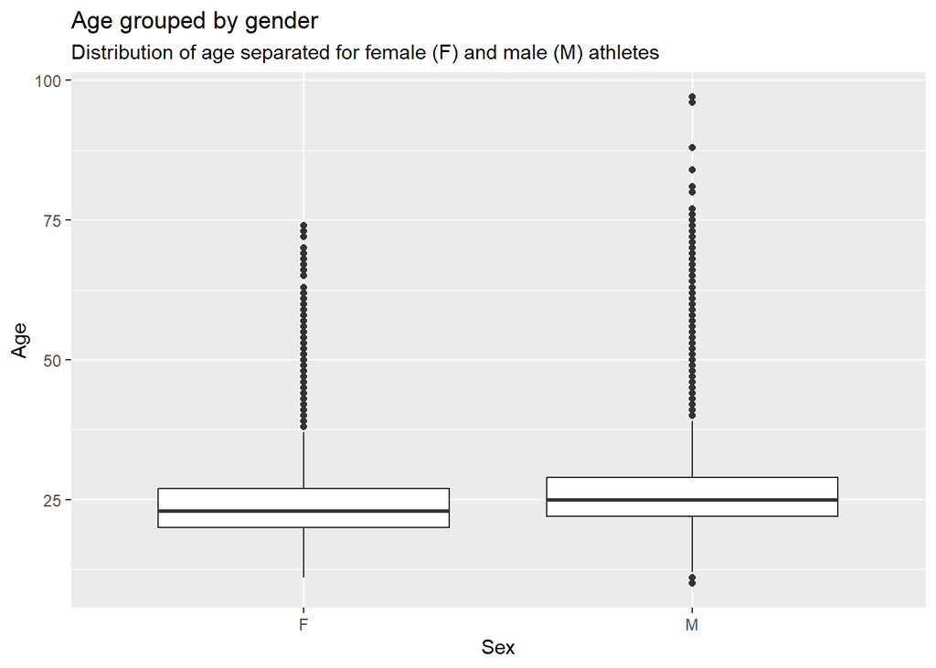

```r
library(ggplot2)
ggplot(atlt_events) +
  geom_boxplot(aes(Sex, Age, group = Sex)) +
  labs( title = "Age grouped by gender", subtitle = "Distribution of age separated for female (F) and male (M) athletes")
```

## distribution of male and female athletes over time

Let us first create a frequency table of the share of women in each Olympic event. Tables are good for looking at factor or character variables.

```r
# Load necessary libraries
library(dplyr)
library(knitr)

share <- atlt_events %>%
  group_by(Year) %>%
  summarize(freq = sum(Sex == 'F') / n(), .groups = 'drop')

# Display the frequency table using kable
kable(share, format = "html", caption = "Table 1: Frequency table of the share of women in each Olympic event")
```

Table 1: Frequency table of the share of women in each Olympic event

| Year | freq |
| --- | --- |
| 1896 | 0.0000000 |
| 1900 | 0.0170455 |
| 1904 | 0.0122982 |
| 1906 | 0.0063474 |
| 1908 | 0.0151564 |
| 1912 | 0.0215347 |
| 1920 | 0.0312209 |
| 1924 | 0.0458458 |
| 1928 | 0.0783997 |
| 1932 | 0.1111111 |
| 1936 | 0.0741792 |
| 1948 | 0.1017380 |
| 1952 | 0.1797393 |
| 1956 | 0.1770283 |
| 1960 | 0.1873308 |
| 1964 | 0.1848101 |
| 1968 | 0.2092757 |
| 1972 | 0.2180784 |
| 1976 | 0.2481432 |
| 1980 | 0.2446011 |
| 1984 | 0.2574215 |
| 1988 | 0.2877487 |
| 1992 | 0.3154816 |
| 1994 | 0.3496835 |
| 1996 | 0.3634253 |
| 1998 | 0.3839112 |
| 2000 | 0.3929528 |
| 2002 | 0.3850085 |
| 2004 | 0.4125567 |
| 2006 | 0.4009585 |
| 2008 | 0.4275842 |
| 2010 | 0.4195820 |
| 2012 | 0.4500774 |
| 2014 | 0.4136168 |
| 2016 | 0.4546318 |

## Wrangling data to find the share of female athletes over time

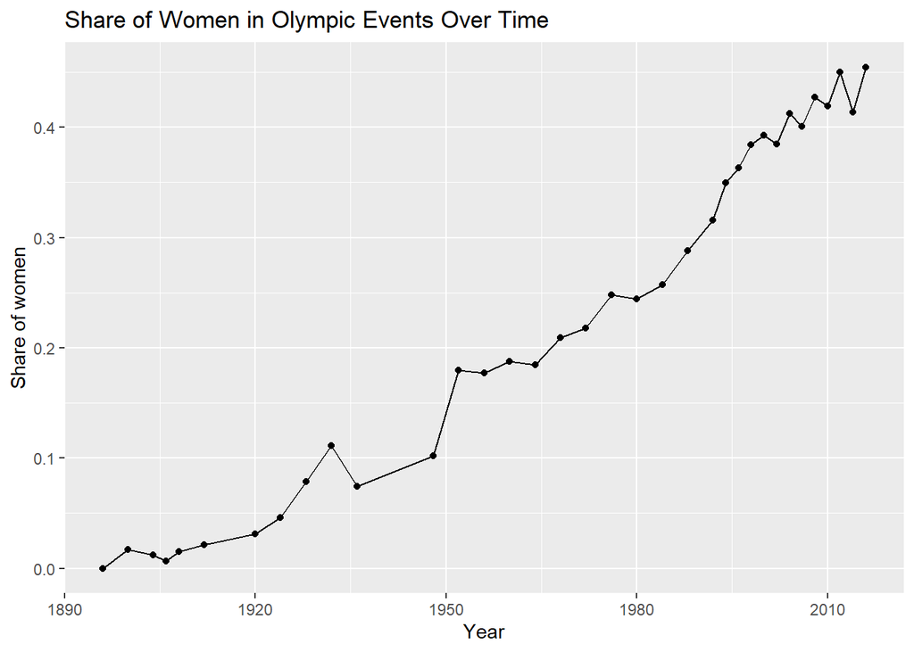

```r
ggplot(share, aes(x = Year, y = freq)) +
  geom_line() +
  geom_point() +
  ylab("Share of women") +
  labs(title = "Share of Women in Olympic Events Over Time")
```

## are taller athletes more likely to win a medal?

To answer this question we can use different methods. We can look at the distribution of height for those who received a medal and those who didn’t. We can first create a variable that indicates whether the athlete has any medal

```r
atlt_events <- atlt_events %>%
  mutate(has.medal=Medal %in% c("Gold", "Silver", "Bronze"))

table(atlt_events$has.medal)
```

```
##
##  FALSE   TRUE
## 231333  39783
```

## Plotting

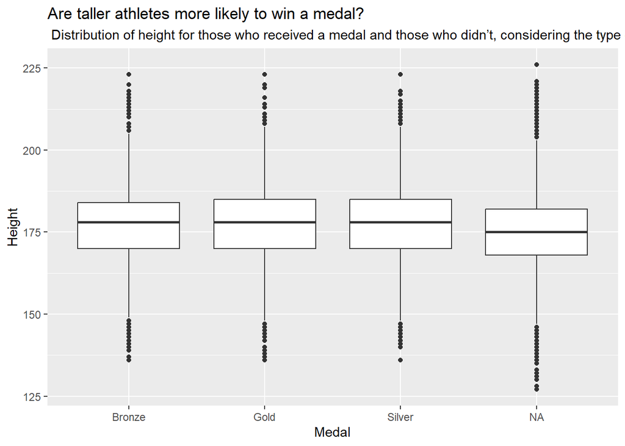

```r
ggplot(atlt_events, aes(x = Medal, y = Height)) +
  geom_boxplot()+
  labs(title = "Are taller athletes more likely to win a medal?", subtitle = " Distribution of height for those who received a medal and those who didn’t, considering the type of medal")
```

## Boxplot for the relationship between height and having won a medal

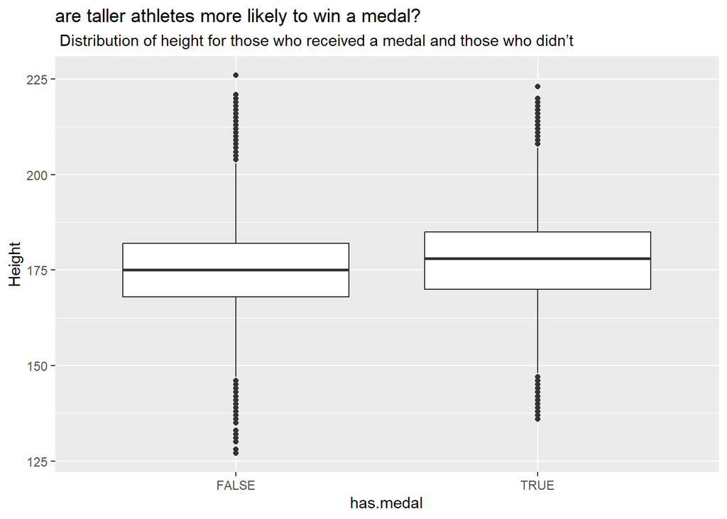

```r
ggplot(atlt_events, aes(x = has.medal, y = Height)) +
  geom_boxplot() +
  labs(title = "are taller athletes more likely to win a medal?", subtitle = " Distribution of height for those who received a medal and those who didn’t")
```

Can we say that being tall increases the probability of winning a medal in the Olympics? The answer to this question is that we don’t know. There are some possible scenarios. For instance, it could be true that being tall increase the chances of winning medals. But it could also be that there are more medals awarded in sports such as volleyball or basketball that require taller athletes.

For now, it’s important to know, as we said in the beginning of this lesson, that association or correlation does not mean causation.